# A note and implementation by python for Barton's coalescent in plane

> Nicholas H. Barton, Jerome Kelleher, Alison M. Etheridge, A NEW MODEL FOR EXTINCTION AND RECOLONIZATION IN TWO DIMENSIONS: QUANTIFYING PHYLOGEOGRAPHY, Evolution, Volume 64, Issue 9, 1 September 2010, Pages 2701–2715, https://doi.org/10.1111/j.1558-5646.2010.01019.x

By: Longxiao 13.03.2025

# Forward process

We firstly go forward step by step:

Initialize parameters, include population density $\rho$, rate of event $\Lambda$, total death rate $u_0$, variance of events distribution $\theta$, and relative strength of parent seeking to extinction $\alpha$.

```python
import numpy as np
import pandas as pd
import matplotlib.pyplot as plt
import matplotlib.cm as cm

#initialize parameters

rho=100
Lambda=1
u0=0.8
theta=0.1
alpha=1
space_size=(1, 1)
seed=123
```

## Poisson distributed initial population

Here we initialize the population. As said in the article, individuals are *scattered over a continuous two-dimensional range in a uniform Poisson distribution with density $\rho$*. As a result, the initial population size follows a Poisson distribution of $\rho \times area$. And individuals are distributed randomly.

```python
'''initialize population'''
population_history = []
events = []
area = space_size[0] * space_size[1]
num_individuals = np.random.poisson(rho * area)

x = np.random.uniform(0, space_size[0], num_individuals)
y = np.random.uniform(0, space_size[1], num_individuals)

population = pd.DataFrame({
    "id": np.arange(1, num_individuals + 1),
    "x": x,
    "y": y,
    "parent_id": None,
    "ancestor_id": np.arange(1, num_individuals + 1)
    })

population_history.append(population.copy())
population
```

|  | id | x | y | parent_id | ancestor_id |
| --- | --- | --- | --- | --- | --- |
| 0 | 1 | 0.904860 | 0.693196 | None | 1 |
| 1 | 2 | 0.455613 | 0.019816 | None | 2 |
| 2 | 3 | 0.955966 | 0.090190 | None | 3 |
| 3 | 4 | 0.590997 | 0.877293 | None | 4 |
| 4 | 5 | 0.199621 | 0.463968 | None | 5 |
| ... | ... | ... | ... | ... | ... |
| 88 | 89 | 0.667488 | 0.330640 | None | 89 |
| 89 | 90 | 0.606192 | 0.910983 | None | 90 |
| 90 | 91 | 0.103685 | 0.166975 | None | 91 |
| 91 | 92 | 0.517172 | 0.273896 | None | 92 |
| 92 | 93 | 0.014645 | 0.172948 | None | 93 |

93 rows × 5 columns

Visualize the initial population distribution:

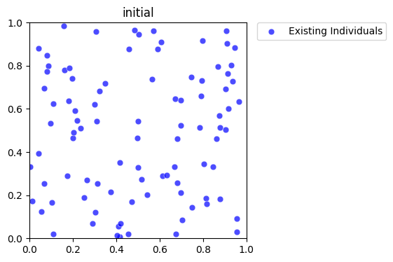

```python
plt.figure(figsize=(4, 4))
plt.xlim(0, space_size[0])
plt.ylim(0, space_size[1])
plt.scatter(population["x"], population["y"],
            s=40, c='blue', alpha=0.7,
            edgecolors='white', linewidths=0.5,
            label='Existing Individuals'
            )
plt.legend(bbox_to_anchor=(1.05, 1), loc=2, borderaxespad=0)
plt.title("initial")
plt.show()
```

## Randomly happend event

Then, the events happen with the rate $\Lambda$, and the center of a event is draw randomly. We use teh function event_gen to generate time interval and the center of a event:

```python
'''a event happens'''
def event_gen():
    dt = np.random.exponential(1 / Lambda)
    z_x = np.random.uniform(0, space_size[0])
    z_y = np.random.uniform(0, space_size[1])
    return dt, z_x, z_y
dt, z_x, z_y = event_gen()
print(dt, z_x, z_y)
```

```
0.23909670589208998 0.37200613069215527 0.5477870709778582
```

Visualize the center of an event

```
<function matplotlib.pyplot.show(close=None, block=None)>
```

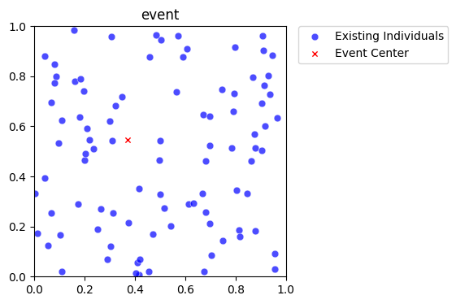

```python
plt.figure(figsize=(4, 4))
plt.xlim(0, space_size[0])
plt.ylim(0, space_size[1])
plt.scatter(population["x"], population["y"],
            s=40, c='blue', alpha=0.7,
            edgecolors='white', linewidths=0.5,
            label='Existing Individuals'
            )
plt.scatter(z_x, z_y,
            s=20, marker='x', c='red',
            linewidths=1, zorder=1,
            label='Event Center'
            )
plt.legend(bbox_to_anchor=(1.05, 1), loc=2, borderaxespad=0)
plt.title("event")
plt.show
```

## Death and birth happend around the event center

Death caused by the event is happened with a probability related to the distance between individual and event center. Specifically, it follows $$ u(z,x) = u_0 e^{-\frac{|z-x|^2}{2\theta^2}} $$ where $z$ is the center and $x$ is the position of a individual. Function ind_death is used to draw individuals that would be dead in the certain event happened in $(z_x, z_y)$.

```python
def ind_death(z_x, z_y,population):

    dx = population["x"] - z_x
    dy = population["y"] - z_y
    squared_dist = dx**2 + dy**2
    death_probs = u0 * np.exp(-squared_dist / (2 * theta**2))
    dead_mask = np.random.rand(len(population)) < death_probs

    survivors = population[~dead_mask].copy()
    survivors["parent_id"] = survivors["id"]
    death = population[dead_mask]

    return survivors, death


survivors, death = ind_death(z_x, z_y, population)
```

Visualize dead individuals

```
<function matplotlib.pyplot.show(close=None, block=None)>
```

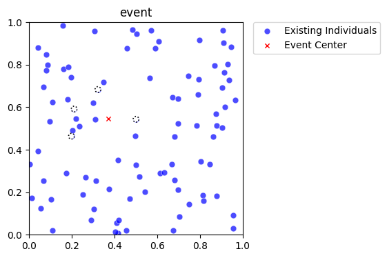

```python
plt.figure(figsize=(4, 4))
plt.xlim(0, space_size[0])
plt.ylim(0, space_size[1])
plt.scatter(population["x"], population["y"],
            s=40, c='blue', alpha=0.7,
            edgecolors='white', linewidths=0.5,
            label='Existing Individuals'
            )
plt.scatter(z_x, z_y,
            s=20, marker='x', c='red',
            linewidths=1, zorder=1,
            label='Event Center'
            )
plt.scatter(death['x'], death['y'],
            linestyle=':', c='white',
            edgecolor='black', linewidth=1.2
            )
plt.legend(bbox_to_anchor=(1.05, 1), loc=2, borderaxespad=0)
plt.title("event")
plt.show
```

The new parent, or the individual reproduce in the event is choosen also follows a normal distribution centered by the event center, but with a variance $(\alpha \cdot \theta)^2$. Basically, it is: $$ v(z,y) = u_0 e^{-\frac{|z-y|^2}{2 (\alpha \cdot \theta)^2}} $$ where $y$ is the position of the new parent.

```python
def ind_parent(z_x, z_y, population):

    s_x = population["x"].values
    s_y = population["y"].values

    s_dx = s_x - z_x
    s_dy = s_y - z_y
    s_dist = s_dx**2 + s_dy**2
    parent_weights = np.exp(-s_dist / (2 * (alpha * theta)**2))
    parent_weights /= parent_weights.sum()

    parent_idx = np.random.choice(len(population), p=parent_weights)
    parent = population.iloc[parent_idx]

    return parent

parent = ind_parent(z_x, z_y, population)
```

Visualize the choosen parent individual

```
<function matplotlib.pyplot.show(close=None, block=None)>
```

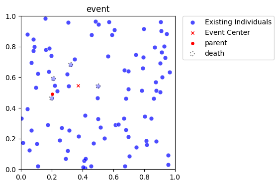

```python
plt.figure(figsize=(4, 4))
plt.xlim(0, space_size[0])
plt.ylim(0, space_size[1])
plt.scatter(population["x"], population["y"],
            s=40, c='blue', alpha=0.7,
            edgecolors='white', linewidths=0.5,
            label='Existing Individuals'
            )
plt.scatter(z_x, z_y,
            s=20, marker='x', c='red',
            linewidths=1, zorder=1,
            label='Event Center'
            )
plt.scatter(parent['x'], parent['y'],
            c='red',
            edgecolor='white', linewidth=1.2,
            label='parent'
            )
plt.scatter(death['x'], death['y'],
            linestyle=':', c='white', alpha=0.5,
            edgecolor='black', linewidth=1.5,
            label='death'
            )

plt.legend(bbox_to_anchor=(1.05, 1), loc=2, borderaxespad=0)
plt.title("event")
plt.show
```

```python
def ind_new(z_x, z_y):
    event_area = 2 * np.pi * theta**2
    expected_new = rho * event_area * u0
    num_new = np.random.poisson(expected_new)

    new_x = np.random.normal(z_x, theta, num_new)
    new_y = np.random.normal(z_y, theta, num_new)

    new_x = new_x[(new_x >= 0)& (new_x <= space_size[0])]
    new_y = new_x[(new_x >= 0)& (new_x <= space_size[0])]

    return new_x, new_y

new_x, new_y = ind_new(z_x, z_y)
```

Visualize new individuals

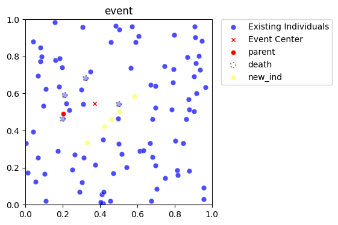

```python
plt.figure(figsize=(4, 4))
plt.xlim(0, space_size[0])
plt.ylim(0, space_size[1])
plt.scatter(population["x"], population["y"],
            s=40, c='blue', alpha=0.7,
            edgecolors='white', linewidths=0.5,
            label='Existing Individuals'
            )
plt.scatter(z_x, z_y,
            s=20, marker='x', c='red',
            linewidths=1, zorder=1,
            label='Event Center'
            )
plt.scatter(parent['x'], parent['y'],
            c='red',
            edgecolor='white', linewidth=0.5,
            label='parent'
            )
plt.scatter(death['x'], death['y'],
            linestyle=':', c='white', alpha=0.5,
            edgecolor='black', linewidth=1.5,
            label='death'
            )
plt.scatter(new_x, new_y,
            c='yellow', alpha=0.5,
            edgecolor='white', linewidth=0.5,
            label='new_ind'
            )

plt.legend(bbox_to_anchor=(1.05, 1), loc=2, borderaxespad=0)
plt.title("event")
```

An event finished. We move the dead individuals and add new individuals to the population, and record population historical state.

```python
def new_population(new_x, new_y, parent, survivors):
    new_individuals = pd.DataFrame({
        "id": None,
        "x": new_x,
        "y": new_y,
        "parent_id": parent['id'],
        "ancestor_id": parent['ancestor_id']
        })
    population = pd.concat([survivors, new_individuals], ignore_index=True)
    population['id'] = np.arange(1, len(population) + 1)
    return population

population = new_population(new_x, new_y, parent, survivors)
```

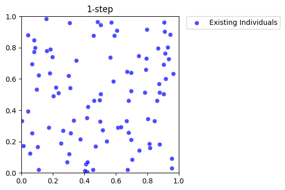

```python
plt.figure(figsize=(4, 4))
plt.xlim(0, space_size[0])
plt.ylim(0, space_size[1])
plt.scatter(population["x"], population["y"],
            s=40, c='blue', alpha=0.7,
            edgecolors='white', linewidths=0.5,
            label='Existing Individuals'
            )
plt.legend(bbox_to_anchor=(1.05, 1), loc=2, borderaxespad=0)
plt.title("1-step")
plt.show()
```

## Longer simulation

For simulation, we now define a function *event*, to iterate on population

```python
def event(population):
    dt, z_x, z_y = event_gen()

    survivors, death = ind_death(z_x, z_y, population)
    parent = ind_parent(z_x, z_y,population)
    new_x, new_y = ind_new(z_x,z_y)
    population = new_population(new_x, new_y, parent, survivors)

    events.append({
            "time": dt,
            "z_x": z_x,
            "z_y": z_y,
            "num_dead": len(death),
            "num_new": len(new_x)
        })

    population_history.append(population.copy())

    return population

population = event(population)
population
```

|  | id | x | y | parent_id | ancestor_id |
| --- | --- | --- | --- | --- | --- |
| 0 | 1 | 0.904860 | 0.693196 | 1.0 | 1.0 |
| 1 | 2 | 0.455613 | 0.019816 | 2.0 | 2.0 |
| 2 | 3 | 0.955966 | 0.090190 | 3.0 | 3.0 |
| 3 | 4 | 0.590997 | 0.877293 | 4.0 | 4.0 |
| 4 | 5 | 0.935941 | 0.727350 | 5.0 | 6.0 |
| ... | ... | ... | ... | ... | ... |
| 95 | 96 | 0.392644 | 0.392644 | 29.0 | 32.0 |
| 96 | 97 | 0.348024 | 0.348024 | 29.0 | 32.0 |
| 97 | 98 | 0.322529 | 0.322529 | 29.0 | 32.0 |
| 98 | 99 | 0.377790 | 0.377790 | 29.0 | 32.0 |
| 99 | 100 | 0.342678 | 0.342678 | 29.0 | 32.0 |

100 rows × 5 columns

## population density kept

```python
def simulate(population, total_time=100):
    """simulate until time limitation"""
    current_time = 0
    event_id = 0
    while current_time < total_time:
        population = event(population)
        current_time += events[event_id]['time']
        event_id += 1

simulate(population)
len(population_history),len(events)
```

```
(477, 476)
```

```
[ 93. 100.  96.  95.  91.  91.  89.  84.  78.  80.  87.  88.  93.  95.
  93.  95.  94.  97.  96. 101. 105. 107.  95.  99.  89.  91.  90.  91.
  95.  94.  96.  96. 103. 107. 112. 113. 113. 116. 121. 129. 114. 118.
 109. 114. 117. 121. 124. 132. 128. 131. 130. 125. 127. 102.  84.  83.
  84.  95.  97.  98.  92.  94.  93.  95.  85.  85.  84.  84.  86.  85.
  87.  90.  88.  94.  96.  98. 103. 103.  99. 104. 107. 101.  98. 103.
 107. 108. 111. 116. 120. 123. 131. 134. 138. 143. 145. 124. 123. 104.
 104. 110. 108. 105. 101. 102. 104. 102.  89.  94.  96.  96. 102. 103.
 101.  98. 106. 109. 110. 103.  96.  99. 101. 102. 107. 105. 102. 102.
 101.  99.  87.  87.  86.  88.  96.  96.  98. 101. 106. 102. 108. 105.
 106. 112. 114. 110. 116. 107. 110. 116. 118. 121. 124. 115. 107. 105.
  96.  98. 100. 107. 116. 103. 104. 110. 115. 120. 120. 124. 123. 129.
 131. 132. 127. 136. 131. 133. 130. 135. 122. 115. 105. 112. 120. 109.
 111. 101. 100. 104. 105. 107. 109. 103.  89.  95.  98.  99.  98.  97.
 104. 108. 110. 103. 108. 106.  97.  98. 103.  99. 104. 105. 108. 102.
  98.  89.  98. 102. 101. 103. 110. 107. 111. 114. 108.  96.  97.  98.
  92.  94.  95.  94. 101. 105. 107. 113. 114. 112. 107. 108.  98.  98.
  85.  84.  88.  87.  83.  88.  95.  98.  93.  95.  89.  99. 101.  93.
  90.  93.  88.  89.  87.  98. 107. 107. 106. 102. 101. 104. 108. 104.
 100. 107. 117. 119. 115. 117. 119. 126. 133. 138. 140. 135. 110. 113.
 117. 114. 117. 124. 108.  99.  98. 102. 102. 105. 103. 103. 107. 102.
 103. 104. 104. 105. 107. 107. 106. 105. 102.  94.  96.  95.  97. 103.
  91.  91.  93.  93.  94.  84.  88.  89.  88.  80.  80.  75.  74.  77.
  80.  84.  88.  94.  93.  99.  94.  95.  96. 100.  97. 101. 110. 115.
 117. 113. 109. 113. 108. 110. 109.  86.  87.  91.  89.  86.  71.  71.
  69.  61.  62.  63.  65.  65.  68.  78.  81.  83.  85.  90.  92.  92.
  88.  92.  93.  95.  99. 102. 105. 105. 106. 107. 112.  98.  97. 101.
  95.  97.  92.  94. 106. 107. 107. 110. 116. 119. 121. 119. 120. 117.
 116. 112. 113. 108. 105. 105. 104. 106.  99.  92.  94.  98.  99.  96.
  97.  96. 104. 104.  94.  93.  81.  83.  84.  87.  83.  82.  83.  88.
  90.  92.  96.  99.  98. 101. 107.  97. 105. 110. 105. 108. 104. 104.
 102. 104. 106. 104.  93.  97.  92.  92.  79.  74.  73.  80.  76.  70.
  74.  73.  74.  77.  71.  73.  75.  76.  81.  85.  92.  80.  84.  75.
  72.  72.  74.  76.  79.  85.  88.  90.  94.  98. 101. 101. 105. 106.
 101.]
```

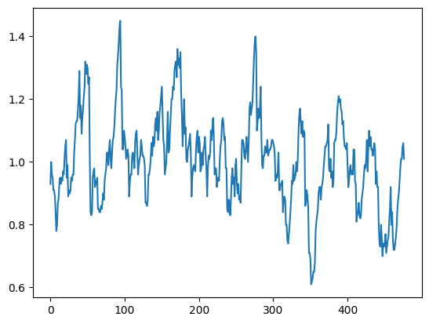

```python
pop_size = np.zeros(len(population_history))
for i in range(len(population_history)):
    pop_size[i] = len(population_history[i])

print(pop_size)
plt.plot(pop_size/rho)
```

## Visualize in 3-D

```python
rho = 20
population_history = []
events = []
area = space_size[0] * space_size[1]
num_individuals = np.random.poisson(rho * area)

x = np.random.uniform(0, space_size[0], num_individuals)
y = np.random.uniform(0, space_size[1], num_individuals)

population = pd.DataFrame({
    "id": np.arange(1, num_individuals + 1),
    "x": x,
    "y": y,
    "parent_id": None,
    "ancestor_id": np.arange(1, num_individuals + 1)
    })

population_history.append(population.copy())
```

```python
simulate(population,total_time=5)
```

```python
import numpy as np
import pandas as pd
import matplotlib.pyplot as plt
from mpl_toolkits.mplot3d import Axes3D

class PopulationHistoryVisualizer:
    def __init__(self, events, population_history, space_size=(1, 1)):
        """
        :param events: 事件列表，每个元素需包含 "time" 字段（时间间隔，非绝对时间）
        :param population_history: 种群历史列表，每个元素为DataFrame，包含 "id", "x", "y", "parent_id"
        :param space_size: 模拟区域大小 (默认1x1)
        """
        self.events = events
        self.population_history = population_history
        self.space_size = space_size
        self.fig = plt.figure(figsize=(6, 6))
        self.ax = self.fig.add_subplot(111, projection='3d')

        # 计算绝对时间
        self.absolute_times = self._calculate_absolute_times()

    def _calculate_absolute_times(self):
        """将事件时间间隔转换为绝对时间"""
        absolute_times = [0.0]  # 初始时间为0
        for event in self.events:
            absolute_times.append(absolute_times[-1] + event["time"])
        return absolute_times

    def plot_3d_history(self):
        """三维时空演化可视化"""

        # 创建颜色映射
        colors = plt.cm.viridis(np.linspace(0, 1, len(self.absolute_times)))

        # 绘制每个时间平面
        for i, (t, df) in enumerate(zip(self.absolute_times, self.population_history)):
            # 绘制时间平面
            self._draw_time_plane(t, color=colors[i], alpha=0.05)

            # 绘制当前时间点个体
            self.ax.scatter(
                df["x"], df["y"], t,
                c=[colors[i]]*len(df),
                s=20, depthshade=False,
                label=f't={t:.2f}'
            )

            # 绘制亲代连线（跳过初始时间）
            if i > 0:
                self._draw_parent_connections(
                    prev_df=self.population_history[i-1],
                    current_df=df,
                    prev_time=self.absolute_times[i-1],
                    current_time=t
                )

        # 设置坐标轴
        self.ax.set_xlim(0, self.space_size[0])
        self.ax.set_ylim(0, self.space_size[1])
        self.ax.set_zlim(0, max(self.absolute_times))
        self.ax.set_xlabel('X')
        self.ax.set_ylabel('Y')
        self.ax.set_zlabel('Time')
        plt.legend()
        plt.show()

    def _draw_time_plane(self, z, color, alpha=0.05):
        """绘制半透明时间平面（逻辑不变）"""
        xx, yy = np.meshgrid(
            np.linspace(0, self.space_size[0], 2),
            np.linspace(0, self.space_size[1], 2)
        )
        zz = np.full_like(xx, z)
        self.ax.plot_surface(
            xx, yy, zz,
            color=color,
            alpha=alpha,
            edgecolor='none'
        )

    def _draw_parent_connections(self, prev_df, current_df, prev_time, current_time):
        """绘制父子代连线（逻辑不变）"""
        parent_map = {
            row["id"]: (row["x"], row["y"], prev_time)
            for _, row in prev_df.iterrows()
        }
        for _, row in current_df.iterrows():
            parent_id = row["parent_id"]
            if parent_id in parent_map:
                x_prev, y_prev, t_prev = parent_map[parent_id]
                x_curr, y_curr = row["x"], row["y"]
                self.ax.plot(
                    [x_prev, x_curr], [y_prev, y_curr], [t_prev, current_time],
                    color='gray', alpha=1, lw=0.5
                )
```

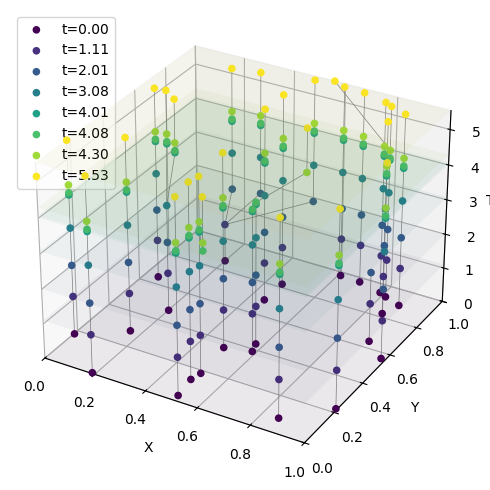

```python
visualizer = PopulationHistoryVisualizer(events, population_history)
visualizer.plot_3d_history()
```

# Backward Process (not finished yet)

```python
import numpy as np
import pandas as pd

theta = 0.1
u0 = 0.8
Lambda = 1
alpha = 1.3
rho = 100
space_size = (1, 1)
population_history = []
events = []
```

```python
def initialize_backward_population(sample_size=10):
    """初始化采样种群（无父代信息）"""
    return pd.DataFrame({
        "x": np.random.uniform(0, space_size[0], sample_size),
        "y": np.random.uniform(0, space_size[1], sample_size),
        "parent_x": None,
        "parent_y": None
    })

population = initialize_backward_population(sample_size=20)
population_history = [population.copy()]
population
```

|  | x | y | parent_x | parent_y |
| --- | --- | --- | --- | --- |
| 0 | 0.868069 | 0.085209 | None | None |
| 1 | 0.364261 | 0.704067 | None | None |
| 2 | 0.563183 | 0.223180 | None | None |
| 3 | 0.173847 | 0.802975 | None | None |
| 4 | 0.847671 | 0.013925 | None | None |
| 5 | 0.831519 | 0.136961 | None | None |
| 6 | 0.134561 | 0.622288 | None | None |
| 7 | 0.899021 | 0.330266 | None | None |
| 8 | 0.552974 | 0.473884 | None | None |
| 9 | 0.103192 | 0.376543 | None | None |
| 10 | 0.612892 | 0.785135 | None | None |
| 11 | 0.012091 | 0.319185 | None | None |
| 12 | 0.148687 | 0.236002 | None | None |
| 13 | 0.191178 | 0.708069 | None | None |
| 14 | 0.591035 | 0.296511 | None | None |
| 15 | 0.156748 | 0.602910 | None | None |
| 16 | 0.832683 | 0.117243 | None | None |
| 17 | 0.686724 | 0.060198 | None | None |
| 18 | 0.115537 | 0.420695 | None | None |
| 19 | 0.676425 | 0.567785 | None | None |

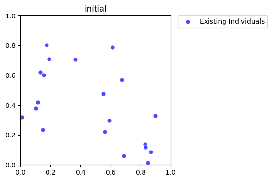

```python
plt.figure(figsize=(4, 4))
plt.xlim(0, space_size[0])
plt.ylim(0, space_size[1])
plt.scatter(population["x"], population["y"],
            s=40, c='blue', alpha=0.7,
            edgecolors='white', linewidths=0.5,
            label='Existing Individuals'
            )
plt.legend(bbox_to_anchor=(1.05, 1), loc=2, borderaxespad=0)
plt.title("initial")
plt.show()
```

```python
def backward_event_gen(current_time):
    rate = Lambda * np.pi * (theta**2) * u0
    dt = np.random.exponential(1/rate)
    z_x, z_y = np.random.uniform(0, space_size[0]), np.random.uniform(0, space_size[1])
    return current_time + dt, (z_x, z_y)

event_time, event_z = backward_event_gen(0)
event_z,event_time
```

```
((0.5082680356856656, 0.43755032261881033), 11.742827337203758)
```

```
<function matplotlib.pyplot.show(close=None, block=None)>
```

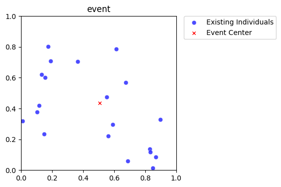

```python
plt.figure(figsize=(4, 4))
plt.xlim(0, space_size[0])
plt.ylim(0, space_size[1])
plt.scatter(population["x"], population["y"],
            s=40, c='blue', alpha=0.7,
            edgecolors='white', linewidths=0.5,
            label='Existing Individuals'
            )
plt.scatter(event_z[0], event_z[1],
            s=20, marker='x', c='red',
            linewidths=1, zorder=1,
            label='Event Center'
            )
plt.legend(bbox_to_anchor=(1.05, 1), loc=2, borderaxespad=0)
plt.title("event")
plt.show
```

```python
def apply_backward_event(population, event_z):
    """应用单个回溯事件"""
    # 计算击中概率
    dx = population.x - event_z[0]
    dy = population.y - event_z[1]
    dist_sq = dx**2 + dy**2
    hit_probs = u0 * np.exp(-dist_sq/(2*theta**2))

    # 选择被击中的个体
    hit_mask = np.random.rand(len(population)) < hit_probs
    if not hit_mask.any():
        return population

    # 生成父代位置（方差θ²(1+α²)）
    sigma_parent = theta * np.sqrt(1 + alpha**2)
    parent_x = np.random.normal(event_z[0], sigma_parent)
    parent_y = np.random.normal(event_z[1], sigma_parent)

    if parent_x*parent_y == 0:
        return population

    # 更新被击中个体的父代信息
    population.loc[hit_mask, "parent_x"] = parent_x
    population.loc[hit_mask, "parent_y"] = parent_y

    # 添加父代个体
    new_parents = pd.DataFrame({
        "x": [parent_x],
        "y": [parent_y],
        "parent_x": None,
        "parent_y": None
    })

    population_history.append(population.copy())

    # 合并种群：未被击中的个体 + 唯一父代
    survivors = population[~hit_mask]
    return population[hit_mask], pd.concat([survivors, new_parents], ignore_index=True)
```

```python
dx = population.x - event_z[0]
dy = population.y - event_z[1]
dist_sq = dx**2 + dy**2
hit_probs = u0 * np.exp(-dist_sq/(2*theta**2))

hit_mask = np.random.rand(len(population)) < hit_probs

hit_pop = population[hit_mask]

sigma_parent = theta * np.sqrt(1 + alpha**2)
parent_x = np.random.normal(event_z[0], sigma_parent)
parent_y = np.random.normal(event_z[1], sigma_parent)
```

[output not shown]

[figure not shown]

```python
plt.figure(figsize=(4, 4))
plt.xlim(0, space_size[0])
plt.ylim(0, space_size[1])
plt.scatter(population["x"], population["y"],
            s=40, c='blue', alpha=0.7,
            edgecolors='white', linewidths=0.5,
            label='Existing Individuals'
            )
plt.scatter(event_z[0], event_z[1],
            s=20, marker='x', c='red',
            linewidths=1, zorder=1,
            label='Event Center'
            )
plt.scatter(parent_x, parent_y,
            c='red',
            edgecolor='white', linewidth=0.5,
            label='parent'
            )
plt.scatter(hit_pop[0], hit_pop[1],
            linestyle=':', c='white', alpha=0.5,
            edgecolor='black', linewidth=1.5,
            label='death'
            )
plt.legend(bbox_to_anchor=(1.05, 1), loc=2, borderaxespad=0)
plt.title("event")
```

```python
def simulate_backward(population, total_events=100):
    """主模拟函数"""
    # 初始化
    current_time = 0

    for i in range(total_events):
        # 生成事件
        event_time, event_z = backward_event_gen(current_time)
        events.append({"time": event_time, "z_x": event_z[0], "z_y": event_z[1]})

        # 应用事件
        population = apply_backward_event(population, event_z)

        # 终止条件：只剩一个个体
        if len(population) == 10:
            break

        current_time = event_time

    return population_history, events

population_history, events = simulate_backward(population, total_events=100)
len(population_history)
```

[output not shown]

# Appendix: Random walk

random walk OR: Brownian motion

"why Kingman coalescent not works for population distributed in plane space?"

## Random walk in 1 dimension

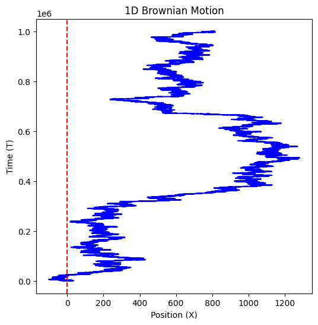

```python
import numpy as np
import matplotlib.pyplot as plt

# 参数设定
T = 1000000 # 总时间步数
x = np.zeros(T)  # 记录每个时间步的位置信息
step_size = 1  # 每步移动的距离

# 生成布朗运动（随机游走）
for t in range(1, T):
    x[t] = x[t-1] + np.random.choice([-step_size, step_size])  # 随机向左或向右移动

# 绘图
plt.figure(figsize=(6, 6))
plt.plot(x, np.arange(T), linestyle='-', markersize=3, color='blue')
plt.axvline(x=0, color='red', linestyle='--', linewidth=1.5, label="x=0 Reference")
plt.xlabel("Position (X)")
plt.ylabel("Time (T)")
plt.title("1D Brownian Motion")
plt.show()
```

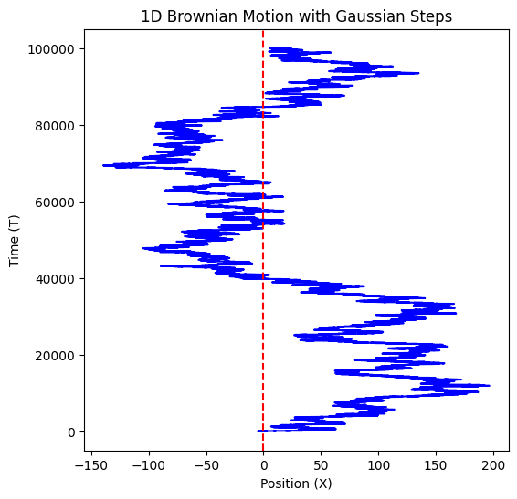

```python
import numpy as np
import matplotlib.pyplot as plt

# 参数设定
T = 100000  # 总时间步数
sigma = 1  # 运动的标准差，控制步长的大小

# 生成布朗运动
x = np.cumsum(np.random.normal(loc=0, scale=sigma, size=T))  # 累积求和，生成连续轨迹

# 绘图
plt.figure(figsize=(6, 6))
plt.plot(x, np.arange(T), linestyle='-', markersize=3, color='blue')
plt.axvline(x=0, color='red', linestyle='--', linewidth=1.5, label="x=0 Reference")
plt.xlabel("Position (X)")
plt.ylabel("Time (T)")
plt.title("1D Brownian Motion with Gaussian Steps")
plt.show()
```

## Random walk in 2 dimension

```python
import numpy as np
import matplotlib.pyplot as plt
from mpl_toolkits.mplot3d import Axes3D

# 参数设定
T = 10000  # 总时间步数
sigma = 1  # 标准差，控制步长大小

# 生成二维布朗运动轨迹
x = np.cumsum(np.random.normal(loc=0, scale=sigma, size=T))  # X方向步长累积
y = np.cumsum(np.random.normal(loc=0, scale=sigma, size=T))  # Y方向步长累积
t = np.arange(T)  # 时间步
```

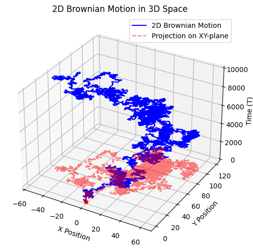

```python
# 创建 3D 图形
fig = plt.figure(figsize=(6, 6))
ax = fig.add_subplot(111, projection='3d')

# 绘制布朗运动轨迹
ax.plot(0, 0, 0, marker = 'o', linestyle='-', markersize=5, color='red')
ax.plot(x, y, t, linestyle='-', markersize=3, color='blue', label="2D Brownian Motion")

# 添加 z=0 的参考平面
ax.plot(x, y, np.zeros_like(t), linestyle="--", color='red', alpha=0.5, label="Projection on XY-plane")

# 设置轴标签
ax.set_xlabel("X Position")
ax.set_ylabel("Y Position")
ax.set_zlabel("Time (T)")
ax.set_title("2D Brownian Motion in 3D Space")

# 添加图例
ax.legend()

# 显示图像
plt.show()
```

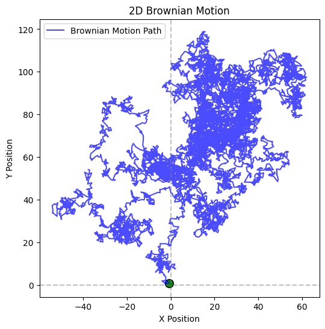

```python
# 绘制二维轨迹
plt.figure(figsize=(6, 6))
plt.plot(x, y, linestyle='-', color='blue', alpha=0.7, label="Brownian Motion Path")

# 标记起点和终点
plt.scatter(x[0], y[0], color='green', s=100, edgecolors='black')

# 添加原点参考线
plt.axhline(y=0, color='gray', linestyle='--', alpha=0.5)
plt.axvline(x=0, color='gray', linestyle='--', alpha=0.5)

# 设置标签和标题
plt.xlabel("X Position")
plt.ylabel("Y Position")
plt.title("2D Brownian Motion")

# 添加图例
plt.legend()

# 显示图像
plt.show()
```